# Caso_Obesidad_Fabio_Fonseca_Jairo_Avila_Juan_Gomez

### Obesidad

Este informe es presentado por Fabio Fonseca, Jairo Avila y Juan Gómez para la materia de Seminario de Programación de la Maestría en Inteligencia de Negocios - MINE V - de la Universidad Externado de Colombia

#### ¿En qué consiste la base de datos?

De acuerdo con lo dispuesto en el portal de Kaggle, este conjunto de datos incluye datos para la estimación de los niveles de obesidad en individuos de los países de México, Perú y Colombia, en función de sus hábitos alimentarios y condición física. Los datos contienen 17 atributos y 2111 registros, los registros están etiquetados con la variable de clase NObesity (Nivel de Obesidad), que permite clasificar los datos utilizando los valores de Peso Insuficiente, Peso Normal, Sobrepeso Nivel I, Sobrepeso Nivel II, Obesidad Tipo I. , Obesidad Tipo II y Obesidad Tipo III. El 77% de los datos se generaron de forma sintética utilizando la herramienta Weka y el filtro SMOTE, el 23% de los datos se recogieron directamente de los usuarios a través de una plataforma web.

los datos originales se encuentran disponibles en el siguiente enlace: https://archive.ics.uci.edu/dataset/544/estimation+of+obesity+levels+based+on+eating+habits+and+physical+condition

```python
pip install gower
```

```python
pip install kmodes
```

```python
# Librerias necesarias

import numpy as np
import pandas as pd
import matplotlib.pyplot as plt
import seaborn as sns
import plotly.offline as py
import plotly.graph_objs as go
import plotly.offline as py
import plotly.express as px
import gower as gw
import seaborn as sns
from sklearn.model_selection import train_test_split
from sklearn.tree import DecisionTreeClassifier
from sklearn.ensemble import RandomForestClassifier
from sklearn.metrics import accuracy_score
from sklearn.preprocessing import LabelEncoder, StandardScaler
from scipy.cluster.hierarchy import linkage, dendrogram
from sklearn.decomposition import PCA
from sklearn.preprocessing import StandardScaler
import matplotlib.pyplot as plt
from kmodes.kprototypes import KPrototypes

ruta='C:/Users/jairo/Downloads/Proyecto/'
```

```python
df = pd.read_csv(ruta + 'ObesityDataSet_raw_and_data_sinthetic.csv')
```

```python
df_copy = pd.read_csv(ruta + 'ObesityDataSet_raw_and_data_sinthetic.csv')
```

#### Diccionario de datos

Los atributos relacionados con los hábitos alimentarios son: Consumo frecuente de alimentos ricos en calorías (FAVC),

Frecuencia de consumo de verduras (FCVC),

Número de comidas principales (NCP),

Consumo de alimentos entre comidas (CAEC),

Consumo de agua diario (CH2O),

Consumo de alcohol (CALC),

Consumo de tabaco (Smoke),

y también se indagó por los antecedentes familiares (family_history_with_overweight).

Los atributos relacionados con la condición física son: Monitoreo del consumo de calorías (SCC),

Frecuencia de actividad física (FAF),

Tiempo de uso de dispositivos tecnológicos (AUT),

Transporte utilizado (MTRANS),

Otras variables fueron: Sexo, Edad, Talla y Peso.

Para efectos de observar en números, se crea una nueva variable IMC, índice de masa corporal, calculada a partir del peso y la altura

```python
df.head()
```

|  | Gender | Age | Height | Weight | family_history_with_overweight | FAVC | FCVC | NCP | CAEC | SMOKE | CH2O | SCC | FAF | TUE | CALC | MTRANS | NObeyesdad |
| --- | --- | --- | --- | --- | --- | --- | --- | --- | --- | --- | --- | --- | --- | --- | --- | --- | --- |
| 0 | Female | 21.0 | 1.62 | 64.0 | yes | no | 2.0 | 3.0 | Sometimes | no | 2.0 | no | 0.0 | 1.0 | no | Public_Transportation | Normal_Weight |
| 1 | Female | 21.0 | 1.52 | 56.0 | yes | no | 3.0 | 3.0 | Sometimes | yes | 3.0 | yes | 3.0 | 0.0 | Sometimes | Public_Transportation | Normal_Weight |
| 2 | Male | 23.0 | 1.80 | 77.0 | yes | no | 2.0 | 3.0 | Sometimes | no | 2.0 | no | 2.0 | 1.0 | Frequently | Public_Transportation | Normal_Weight |
| 3 | Male | 27.0 | 1.80 | 87.0 | no | no | 3.0 | 3.0 | Sometimes | no | 2.0 | no | 2.0 | 0.0 | Frequently | Walking | Overweight_Level_I |
| 4 | Male | 22.0 | 1.78 | 89.8 | no | no | 2.0 | 1.0 | Sometimes | no | 2.0 | no | 0.0 | 0.0 | Sometimes | Public_Transportation | Overweight_Level_II |

```python
df_copy['IMC'] = df_copy['Weight']/df['Height']**2
```

```python
df_copy.head()
```

|  | Gender | Age | Height | Weight | family_history_with_overweight | FAVC | FCVC | NCP | CAEC | SMOKE | CH2O | SCC | FAF | TUE | CALC | MTRANS | NObeyesdad | IMC |
| --- | --- | --- | --- | --- | --- | --- | --- | --- | --- | --- | --- | --- | --- | --- | --- | --- | --- | --- |
| 0 | Female | 21.0 | 1.62 | 64.0 | yes | no | 2.0 | 3.0 | Sometimes | no | 2.0 | no | 0.0 | 1.0 | no | Public_Transportation | Normal_Weight | 24.386526 |
| 1 | Female | 21.0 | 1.52 | 56.0 | yes | no | 3.0 | 3.0 | Sometimes | yes | 3.0 | yes | 3.0 | 0.0 | Sometimes | Public_Transportation | Normal_Weight | 24.238227 |
| 2 | Male | 23.0 | 1.80 | 77.0 | yes | no | 2.0 | 3.0 | Sometimes | no | 2.0 | no | 2.0 | 1.0 | Frequently | Public_Transportation | Normal_Weight | 23.765432 |
| 3 | Male | 27.0 | 1.80 | 87.0 | no | no | 3.0 | 3.0 | Sometimes | no | 2.0 | no | 2.0 | 0.0 | Frequently | Walking | Overweight_Level_I | 26.851852 |
| 4 | Male | 22.0 | 1.78 | 89.8 | no | no | 2.0 | 1.0 | Sometimes | no | 2.0 | no | 0.0 | 0.0 | Sometimes | Public_Transportation | Overweight_Level_II | 28.342381 |

```python
df.dtypes
```

```
Gender                             object
Age                               float64
Height                            float64
Weight                            float64
family_history_with_overweight     object
FAVC                               object
FCVC                              float64
NCP                               float64
CAEC                               object
SMOKE                              object
CH2O                              float64
SCC                                object
FAF                               float64
TUE                               float64
CALC                               object
MTRANS                             object
NObeyesdad                         object
dtype: object
```

```python
#Tamaño de la base de datos.
print(f"data shape: {df.shape}")
```

```
data shape: (2111, 17)
```

```python
df.describe()
```

|  | Age | Height | Weight | FCVC | NCP | CH2O | FAF | TUE |
| --- | --- | --- | --- | --- | --- | --- | --- | --- |
| count | 2111.000000 | 2111.000000 | 2111.000000 | 2111.000000 | 2111.000000 | 2111.000000 | 2111.000000 | 2111.000000 |
| mean | 24.312600 | 1.701677 | 86.586058 | 2.419043 | 2.685628 | 2.008011 | 1.010298 | 0.657866 |
| std | 6.345968 | 0.093305 | 26.191172 | 0.533927 | 0.778039 | 0.612953 | 0.850592 | 0.608927 |
| min | 14.000000 | 1.450000 | 39.000000 | 1.000000 | 1.000000 | 1.000000 | 0.000000 | 0.000000 |
| 25% | 19.947192 | 1.630000 | 65.473343 | 2.000000 | 2.658738 | 1.584812 | 0.124505 | 0.000000 |
| 50% | 22.777890 | 1.700499 | 83.000000 | 2.385502 | 3.000000 | 2.000000 | 1.000000 | 0.625350 |
| 75% | 26.000000 | 1.768464 | 107.430682 | 3.000000 | 3.000000 | 2.477420 | 1.666678 | 1.000000 |
| max | 61.000000 | 1.980000 | 173.000000 | 3.000000 | 4.000000 | 3.000000 | 3.000000 | 2.000000 |

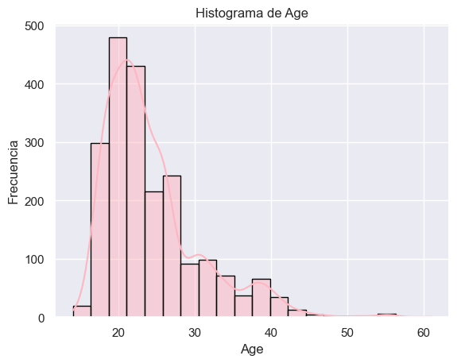

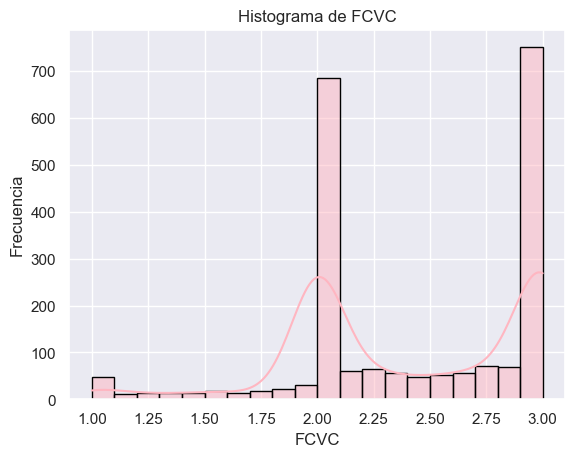

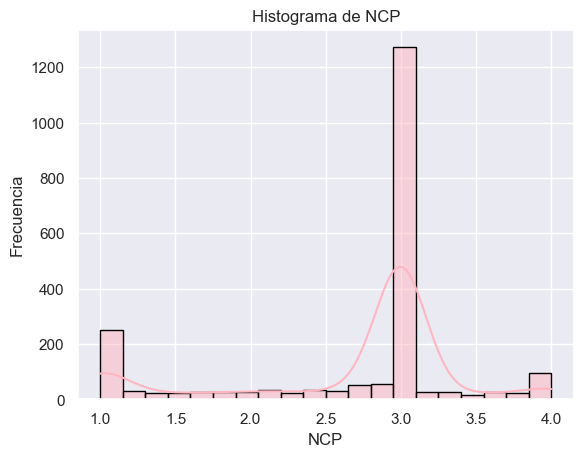

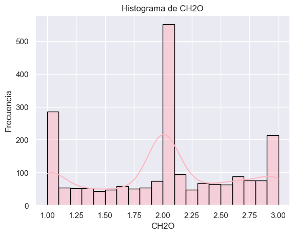

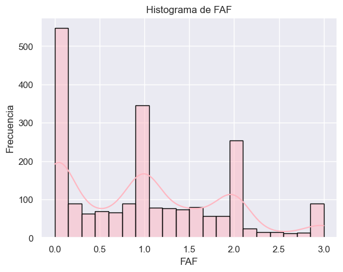

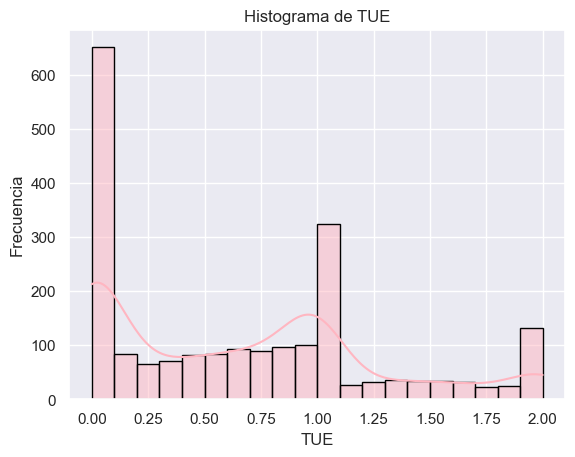

```python
for i in ['Age', 'FCVC', 'NCP', 'CH2O', 'FAF', 'TUE']:
    # Creando el histograma
    sns.histplot(df[i], bins=20, color='lightpink', edgecolor='black', kde=True)

    # Agregando etiquetas y título
    plt.xlabel(i)
    plt.ylabel('Frecuencia')
    plt.title('Histograma de '+i)

    # Mostrando el histograma
    plt.show()
```

Univariate analysis

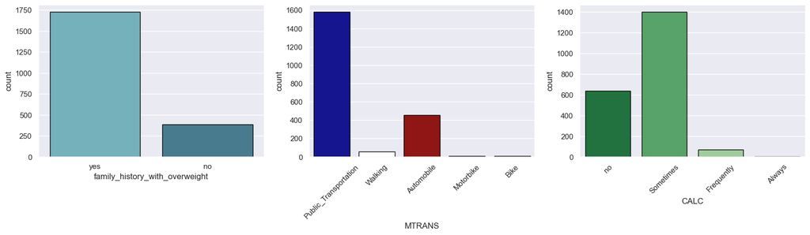

```python
plt.figure(figsize=(20,4))
plt.subplot(131)
sns.countplot(x= 'family_history_with_overweight', data = df, palette="GnBu_d",edgecolor="black")
plt.subplot(132)
sns.countplot(x= 'MTRANS', data = df, palette="flag",edgecolor="black")
plt.xticks(rotation=45)
plt.subplot(133)
sns.countplot(x= 'CALC', data = df, palette="Greens_r",edgecolor="black")
plt.xticks(rotation=45)
plt.show()
```

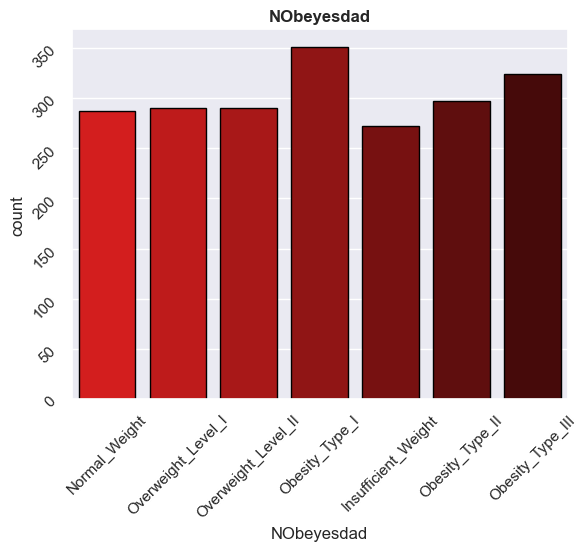

```python
sns.countplot(x="NObeyesdad",data=df,palette="flag",edgecolor="black")
plt.title('NObeyesdad', weight='bold')
plt.xticks(rotation=45)
plt.yticks(rotation=45)
# changing the font size
sns.set(font_scale=1)
```

Bivariate analysis

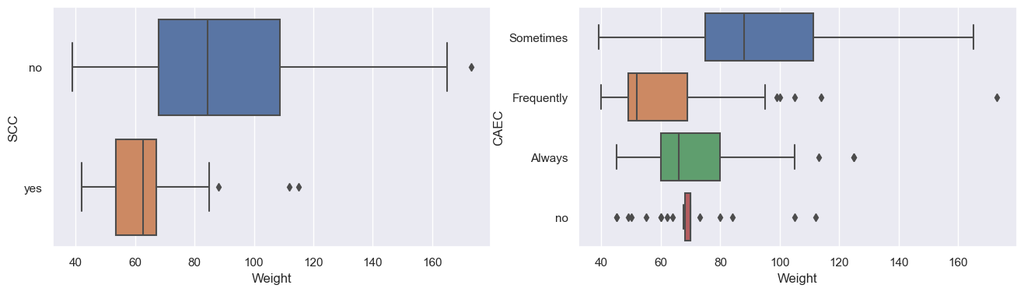

```python
plt.figure(figsize=(16, 4))
plt.subplot(121)
sns.boxplot(x = 'Weight', y = 'SCC', data = df)
plt.subplot(122)
sns.boxplot(x = 'Weight', y = 'CAEC', data = df)

plt.show()
```

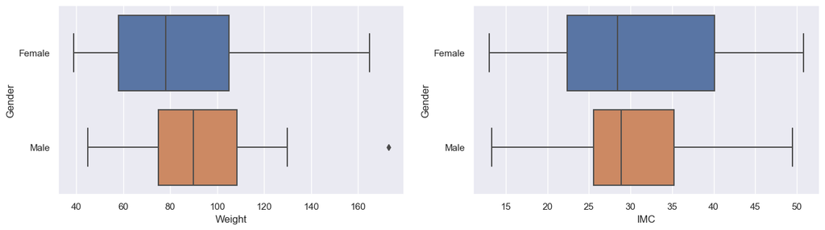

```python
plt.figure(figsize=(16, 4))
plt.subplot(121)
sns.boxplot(x = 'Weight', y = 'Gender', data = df)
plt.subplot(122)
sns.boxplot(x = 'IMC', y = 'Gender', data = df_copy)
```

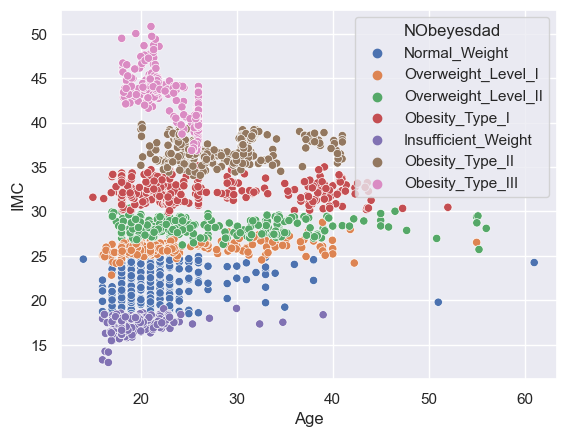

```python
sns.scatterplot(data=df_copy,x='Age',y='IMC',hue='NObeyesdad')
```

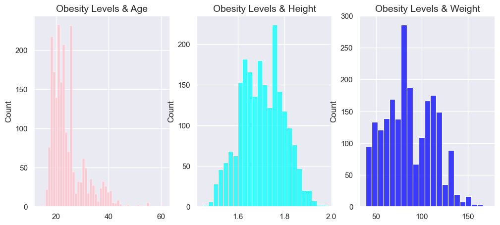

```python
# Distribución de los niveles de obesidad y algunas variables numéricas
fig , ax = plt.subplots(1,3,figsize = (12,5))

Age = df.Age.values
Height= df.Height.values
Weight = df.Weight.values

sns.histplot(Age , ax = ax[0] , color = 'pink').set_title('Obesity Levels & Age', fontsize = 14)
sns.histplot(Height , ax = ax[1] , color = 'cyan').set_title('Obesity Levels & Height', fontsize = 14)
sns.histplot(Weight , ax = ax[2] , color = 'blue').set_title('Obesity Levels & Weight', fontsize = 14)

plt.show()
```

#### Análisis de Componentes Principales

```python
# Seleccionar las columnas numéricas (omitir columnas no numéricas si las hay)
numeric_data = df.select_dtypes(include=[float, int])
numeric_data.columns
```

```
Index(['Age', 'Height', 'Weight', 'FCVC', 'NCP', 'CH2O', 'FAF', 'TUE'], dtype='object')
```

```
[[-0.52212439 -0.87558934 -0.86255819 ... -0.01307326 -1.18803911
   0.56199675]
 [-0.52212439 -1.94759928 -1.16807699 ...  1.61875854  2.33975012
  -1.08062463]
 [-0.20688898  1.05402854 -0.36609013 ... -0.01307326  1.16382038
   0.56199675]
 ...
 [-0.28190933  0.54167211  1.79886776 ...  0.0753606   0.47497132
  -0.01901815]
 [ 0.00777624  0.40492652  1.78577968 ...  1.37780063  0.15147069
  -0.11799101]
 [-0.10211908  0.39834438  1.7905916  ...  1.39603472  0.01899633
   0.09243207]]
```

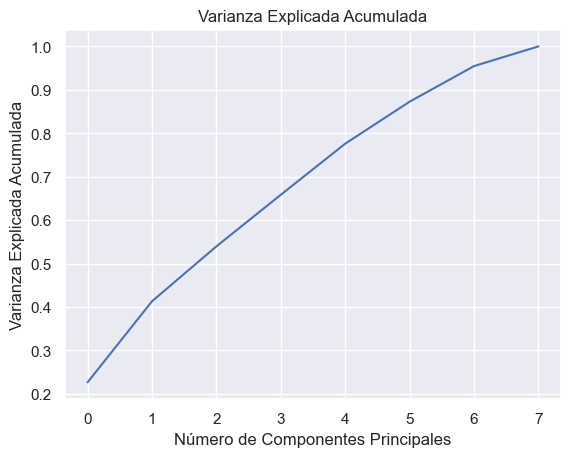

```python
# Normalizar los datos para que tengan media 0 y varianza 1
#scaler = StandardScaler()
scaled_data = scaler.fit_transform(numeric_data)
print(scaled_data)

# Realizar el análisis de componentes principales (PCA)
pca = PCA()
principal_components = pca.fit_transform(scaled_data)

# Explorar la varianza explicada por cada componente
explained_variance = pca.explained_variance_ratio_

# Graficar la varianza explicada acumulada
cumulative_explained_variance = explained_variance.cumsum()
plt.plot(cumulative_explained_variance)
plt.xlabel('Número de Componentes Principales')
plt.ylabel('Varianza Explicada Acumulada')
plt.title('Varianza Explicada Acumulada')
plt.show()
```

```
Componente 1: Varianza Explicada = 0.2265
Componente 2: Varianza Explicada = 0.1866
Componente 3: Varianza Explicada = 0.1265
Componente 4: Varianza Explicada = 0.1189
Componente 5: Varianza Explicada = 0.1176
Componente 6: Varianza Explicada = 0.0967
Componente 7: Varianza Explicada = 0.0819
Componente 8: Varianza Explicada = 0.0454

Varianza Explicada Acumulada:
Componente 1: Varianza Explicada Acumulada = 0.2265
Componente 2: Varianza Explicada Acumulada = 0.4131
Componente 3: Varianza Explicada Acumulada = 0.5395
Componente 4: Varianza Explicada Acumulada = 0.6584
Componente 5: Varianza Explicada Acumulada = 0.7760
Componente 6: Varianza Explicada Acumulada = 0.8727
Componente 7: Varianza Explicada Acumulada = 0.9546
Componente 8: Varianza Explicada Acumulada = 1.0000

Varianza explicada por cada componente principal:
[0.22648604 0.18657893 0.12645386 0.11886405 0.11757848 0.09672213
 0.08194625 0.04537026]

Varianza explicada acumulada:
[0.22648604 0.41306498 0.53951884 0.65838289 0.77596136 0.87268349
 0.95462974 1.        ]
```

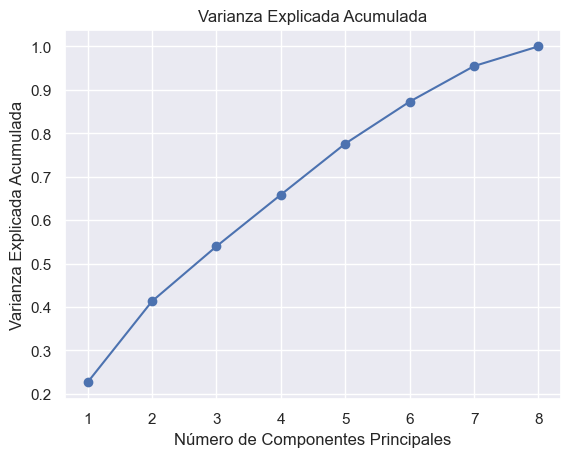

```python
for i, ev in enumerate(explained_variance, start=1):
    print(f'Componente {i}: Varianza Explicada = {ev:.4f}')

# Imprimir la varianza explicada acumulada
print('\nVarianza Explicada Acumulada:')
for i, cev in enumerate(cumulative_explained_variance, start=1):
    print(f'Componente {i}: Varianza Explicada Acumulada = {cev:.4f}')

# Estadísticas descriptivas para los componentes principales
print("\nVarianza explicada por cada componente principal:")
print(pca.explained_variance_ratio_)
print("\nVarianza explicada acumulada:")
print(pca.explained_variance_ratio_.cumsum())

# Visualizar gráficamente la varianza explicada acumulada
import matplotlib.pyplot as plt
plt.plot(range(1, len(explained_variance) + 1), cumulative_explained_variance, marker='o')
plt.xlabel('Número de Componentes Principales')
plt.ylabel('Varianza Explicada Acumulada')
plt.title('Varianza Explicada Acumulada')
plt.show()
```

```python
df0 = pd.DataFrame(scaled_data,
    columns = ["Age","Height","Weight","FCVC","NCP","CH2O","FAF","TUE"])
#df0 = pd.DataFrame(numeric_data)
df0.head()
```

|  | Age | Height | Weight | FCVC | NCP | CH2O | FAF | TUE |
| --- | --- | --- | --- | --- | --- | --- | --- | --- |
| 0 | -0.522124 | -0.875589 | -0.862558 | -0.785019 | 0.404153 | -0.013073 | -1.188039 | 0.561997 |
| 1 | -0.522124 | -1.947599 | -1.168077 | 1.088342 | 0.404153 | 1.618759 | 2.339750 | -1.080625 |
| 2 | -0.206889 | 1.054029 | -0.366090 | -0.785019 | 0.404153 | -0.013073 | 1.163820 | 0.561997 |
| 3 | 0.423582 | 1.054029 | 0.015808 | 1.088342 | 0.404153 | -0.013073 | 1.163820 | -1.080625 |
| 4 | -0.364507 | 0.839627 | 0.122740 | -0.785019 | -2.167023 | -0.013073 | -1.188039 | -1.080625 |

Los datos anteriores indican que, para acoger entre el 80% y el 90% de la varianza acumulada, se requieren 6 componentes principales. Teniendo en cuenta que sólo hay 8 variables numéricas, se infiere que es indispensable utilizar las variables categóricas en el análisis. Por tanto, se aplicará el análisis de K-prototypes

#### Análisis de K-Prototypes

Para aplicar el análisis de K-prototypes se requiere transformar las variables categóricas a variables dummy para cada uno de sus niveles y concatenar esta base con el data frame estandarizado, que se generó en el análisis de PCA. A aprtir de allí, se calcula la matriz de correlación

```python
# Seleccionar las columnas categóricas
df1 = df.select_dtypes(include=['object'])
df1.columns
df1.head()
```

|  | Gender | family_history_with_overweight | FAVC | CAEC | SMOKE | SCC | CALC | MTRANS | NObeyesdad |
| --- | --- | --- | --- | --- | --- | --- | --- | --- | --- |
| 0 | Female | yes | no | Sometimes | no | no | no | Public_Transportation | Normal_Weight |
| 1 | Female | yes | no | Sometimes | yes | yes | Sometimes | Public_Transportation | Normal_Weight |
| 2 | Male | yes | no | Sometimes | no | no | Frequently | Public_Transportation | Normal_Weight |
| 3 | Male | no | no | Sometimes | no | no | Frequently | Walking | Overweight_Level_I |
| 4 | Male | no | no | Sometimes | no | no | Sometimes | Public_Transportation | Overweight_Level_II |

```python
# Codificar las columnas categóricas
df2 = df1[df1.columns[:8]]
df2.head()
```

|  | Gender | family_history_with_overweight | FAVC | CAEC | SMOKE | SCC | CALC | MTRANS |
| --- | --- | --- | --- | --- | --- | --- | --- | --- |
| 0 | Female | yes | no | Sometimes | no | no | no | Public_Transportation |
| 1 | Female | yes | no | Sometimes | yes | yes | Sometimes | Public_Transportation |
| 2 | Male | yes | no | Sometimes | no | no | Frequently | Public_Transportation |
| 3 | Male | no | no | Sometimes | no | no | Frequently | Walking |
| 4 | Male | no | no | Sometimes | no | no | Sometimes | Public_Transportation |

```python
# Transformar las variables categóricas a dummy
dummy_columns = {
    'Gender': {
        'prefix': 'Gender',
        'sep': ';'},
    'family_history_with_overweight':{
        'prefix': 'family_history',
        'sep': ';'},
    'FAVC':{
        'prefix': 'FAVC',
        'sep': ';'},
    'CAEC':{
        'prefix': 'CAEC',
        'sep': ';'},
    'SMOKE':{
        'prefix': 'SMOKE',
        'sep': ';'},
    'SCC':{
        'prefix': 'SCC',
        'sep': ';'},
    'CALC':{
        'prefix': 'CALC',
        'sep': ';'},
    'MTRANS':{
        'prefix': 'MTRANS',
        'sep': ';'}
}

for column_name, dummy_data in dummy_columns.items():
    # Recogemos un DataFrame con una columna dummy por cada valor
    dummies = df2[column_name].str.get_dummies(sep=dummy_data['sep'])

    # Añadimos `prefix` a cada columna
    dummies.columns = map(lambda col: f'{dummy_data["prefix"]}_{col}', dummies.columns)

    # Añadimos las columnas dummy al df original
    df2 = pd.concat([df2, dummies], axis=1)

# [Opcional] Eliminamos las columnas originales de df
df3 = df2.drop(columns=dummy_columns.keys())

# Ahora df1.head() mostrará las columnas dummy
df3.head()
```

|  | Gender_Female | Gender_Male | family_history_no | family_history_yes | FAVC_no | FAVC_yes | CAEC_Always | CAEC_Frequently | CAEC_Sometimes | CAEC_no | ... | SCC_yes | CALC_Always | CALC_Frequently | CALC_Sometimes | CALC_no | MTRANS_Automobile | MTRANS_Bike | MTRANS_Motorbike | MTRANS_Public_Transportation | MTRANS_Walking |
| --- | --- | --- | --- | --- | --- | --- | --- | --- | --- | --- | --- | --- | --- | --- | --- | --- | --- | --- | --- | --- | --- |
| 0 | 1 | 0 | 0 | 1 | 1 | 0 | 0 | 0 | 1 | 0 | ... | 0 | 0 | 0 | 0 | 1 | 0 | 0 | 0 | 1 | 0 |
| 1 | 1 | 0 | 0 | 1 | 1 | 0 | 0 | 0 | 1 | 0 | ... | 1 | 0 | 0 | 1 | 0 | 0 | 0 | 0 | 1 | 0 |
| 2 | 0 | 1 | 0 | 1 | 1 | 0 | 0 | 0 | 1 | 0 | ... | 0 | 0 | 1 | 0 | 0 | 0 | 0 | 0 | 1 | 0 |
| 3 | 0 | 1 | 1 | 0 | 1 | 0 | 0 | 0 | 1 | 0 | ... | 0 | 0 | 1 | 0 | 0 | 0 | 0 | 0 | 0 | 1 |
| 4 | 0 | 1 | 1 | 0 | 1 | 0 | 0 | 0 | 1 | 0 | ... | 0 | 0 | 0 | 1 | 0 | 0 | 0 | 0 | 1 | 0 |

5 rows × 23 columns

```python
# Conformamos un solo Data Frame con las variables numéricas estandarizadas y las variables categóricas en duumy
df4 = pd.concat([df0, df3], axis=1)

df4.head()
```

|  | Age | Height | Weight | FCVC | NCP | CH2O | FAF | TUE | Gender_Female | Gender_Male | ... | SCC_yes | CALC_Always | CALC_Frequently | CALC_Sometimes | CALC_no | MTRANS_Automobile | MTRANS_Bike | MTRANS_Motorbike | MTRANS_Public_Transportation | MTRANS_Walking |
| --- | --- | --- | --- | --- | --- | --- | --- | --- | --- | --- | --- | --- | --- | --- | --- | --- | --- | --- | --- | --- | --- |
| 0 | -0.522124 | -0.875589 | -0.862558 | -0.785019 | 0.404153 | -0.013073 | -1.188039 | 0.561997 | 1 | 0 | ... | 0 | 0 | 0 | 0 | 1 | 0 | 0 | 0 | 1 | 0 |
| 1 | -0.522124 | -1.947599 | -1.168077 | 1.088342 | 0.404153 | 1.618759 | 2.339750 | -1.080625 | 1 | 0 | ... | 1 | 0 | 0 | 1 | 0 | 0 | 0 | 0 | 1 | 0 |
| 2 | -0.206889 | 1.054029 | -0.366090 | -0.785019 | 0.404153 | -0.013073 | 1.163820 | 0.561997 | 0 | 1 | ... | 0 | 0 | 1 | 0 | 0 | 0 | 0 | 0 | 1 | 0 |
| 3 | 0.423582 | 1.054029 | 0.015808 | 1.088342 | 0.404153 | -0.013073 | 1.163820 | -1.080625 | 0 | 1 | ... | 0 | 0 | 1 | 0 | 0 | 0 | 0 | 0 | 0 | 1 |
| 4 | -0.364507 | 0.839627 | 0.122740 | -0.785019 | -2.167023 | -0.013073 | -1.188039 | -1.080625 | 0 | 1 | ... | 0 | 0 | 0 | 1 | 0 | 0 | 0 | 0 | 1 | 0 |

5 rows × 31 columns

```python
# Calcular la matriz de distancias de Gower
gower_dist = gw.gower_matrix(df4)
gower_dist
```

```
array([[0.        , 0.28220582, 0.1659954 , ..., 0.19281603, 0.20410563,
        0.20052278],
       [0.28220582, 0.        , 0.34067434, ..., 0.2701602 , 0.25967568,
        0.2622874 ],
       [0.1659954 , 0.34067434, 0.        , ..., 0.23943791, 0.25754312,
        0.2564577 ],
       ...,
       [0.19281603, 0.2701602 , 0.23943791, ..., 0.        , 0.01892355,
        0.01996613],
       [0.20410563, 0.25967568, 0.25754312, ..., 0.01892355, 0.        ,
        0.00400397],
       [0.20052278, 0.2622874 , 0.2564577 , ..., 0.01996613, 0.00400397,
        0.        ]], dtype=float32)
```

```python
correlation_matrix  = df4.corr()
correlation_matrix
```

|  | Age | Height | Weight | FCVC | NCP | CH2O | FAF | TUE | Gender_Female | Gender_Male | ... | SCC_yes | CALC_Always | CALC_Frequently | CALC_Sometimes | CALC_no | MTRANS_Automobile | MTRANS_Bike | MTRANS_Motorbike | MTRANS_Public_Transportation | MTRANS_Walking |
| --- | --- | --- | --- | --- | --- | --- | --- | --- | --- | --- | --- | --- | --- | --- | --- | --- | --- | --- | --- | --- | --- |
| Age | 1.000000 | -0.025958 | 0.202560 | 0.016291 | -0.043944 | -0.045304 | -0.144938 | -0.296931 | -0.048394 | 0.048394 | ... | -0.116283 | -0.011367 | 0.082566 | -0.012483 | -0.018803 | 0.604683 | 0.003652 | 0.020286 | -0.554448 | -0.063064 |
| Height | -0.025958 | 1.000000 | 0.463136 | -0.038121 | 0.243672 | 0.213376 | 0.294709 | 0.051912 | -0.618466 | 0.618466 | ... | -0.133753 | -0.000391 | 0.045518 | 0.107070 | -0.127828 | 0.077851 | 0.028996 | -0.010471 | -0.089684 | 0.036951 |
| Weight | 0.202560 | 0.463136 | 1.000000 | 0.216125 | 0.107469 | 0.200575 | -0.051436 | -0.071561 | -0.161668 | 0.161668 | ... | -0.201906 | -0.017947 | -0.041778 | 0.259599 | -0.249828 | -0.013619 | -0.021745 | -0.037300 | 0.059332 | -0.100805 |
| FCVC | 0.016291 | -0.038121 | 0.216125 | 1.000000 | 0.042216 | 0.068461 | 0.019939 | -0.101135 | 0.274505 | -0.274505 | ... | 0.071852 | -0.017090 | -0.018655 | 0.082804 | -0.077072 | -0.061049 | -0.029843 | -0.007512 | 0.057966 | 0.013991 |
| NCP | -0.043944 | 0.243672 | 0.107469 | 0.042216 | 1.000000 | 0.057088 | 0.129504 | 0.036326 | -0.067600 | 0.067600 | ... | -0.015624 | -0.047176 | -0.019126 | 0.099280 | -0.092407 | 0.053424 | 0.023312 | 0.003875 | -0.056849 | 0.006502 |
| CH2O | -0.045304 | 0.213376 | 0.200575 | 0.068461 | 0.057088 | 1.000000 | 0.167236 | 0.011965 | -0.107930 | 0.107930 | ... | 0.008036 | -0.000285 | 0.049442 | 0.062251 | -0.083272 | -0.046237 | 0.026139 | -0.000946 | 0.037504 | 0.008307 |
| FAF | -0.144938 | 0.294709 | -0.051436 | 0.019939 | 0.129504 | 0.167236 | 1.000000 | 0.058562 | -0.189607 | 0.189607 | ... | 0.074221 | -0.000264 | 0.054739 | -0.136138 | 0.118678 | 0.002347 | 0.067129 | -0.016351 | -0.048751 | 0.108927 |
| TUE | -0.296931 | 0.051912 | -0.071561 | -0.101135 | 0.036326 | 0.011965 | 0.058562 | 1.000000 | -0.017269 | 0.017269 | ... | -0.010928 | 0.047995 | 0.060964 | -0.102871 | 0.079755 | -0.165111 | -0.021725 | -0.067402 | 0.143597 | 0.073404 |
| Gender_Female | -0.048394 | -0.618466 | -0.161668 | 0.274505 | -0.067600 | -0.107930 | -0.189607 | -0.017269 | 1.000000 | -1.000000 | ... | 0.102633 | -0.021514 | -0.034848 | 0.037694 | -0.024163 | -0.137560 | -0.057001 | -0.045203 | 0.160184 | -0.039317 |
| Gender_Male | 0.048394 | 0.618466 | 0.161668 | -0.274505 | 0.067600 | 0.107930 | 0.189607 | 0.017269 | -1.000000 | 1.000000 | ... | -0.102633 | 0.021514 | 0.034848 | -0.037694 | 0.024163 | 0.137560 | 0.057001 | 0.045203 | -0.160184 | 0.039317 |
| family_history_no | -0.205725 | -0.247684 | -0.496820 | -0.040372 | -0.071370 | -0.147437 | 0.056673 | -0.022943 | 0.102512 | -0.102512 | ... | 0.185422 | -0.010282 | 0.022154 | 0.024637 | -0.033482 | -0.099327 | 0.015435 | 0.051011 | 0.058927 | 0.067076 |
| family_history_yes | 0.205725 | 0.247684 | 0.496820 | 0.040372 | 0.071370 | 0.147437 | -0.056673 | 0.022943 | -0.102512 | 0.102512 | ... | -0.185422 | 0.010282 | -0.022154 | -0.024637 | 0.033482 | 0.099327 | -0.015435 | -0.051011 | -0.058927 | -0.067076 |
| FAVC_no | -0.063902 | -0.178364 | -0.272300 | 0.027283 | 0.007000 | -0.009719 | 0.107995 | -0.068417 | 0.064934 | -0.064934 | ... | 0.190658 | -0.007888 | 0.056795 | -0.139611 | 0.121809 | -0.057597 | 0.082005 | 0.035401 | -0.028539 | 0.179473 |
| FAVC_yes | 0.063902 | 0.178364 | 0.272300 | -0.027283 | -0.007000 | 0.009719 | -0.107995 | 0.068417 | -0.064934 | 0.064934 | ... | -0.190658 | 0.007888 | -0.056795 | 0.139611 | -0.121809 | 0.057597 | -0.082005 | -0.035401 | 0.028539 | -0.179473 |
| CAEC_Always | -0.031292 | 0.004580 | -0.094966 | -0.018204 | 0.025931 | 0.002843 | 0.022981 | 0.020557 | -0.019296 | 0.019296 | ... | 0.081236 | -0.003494 | 0.088654 | -0.045979 | 0.012897 | 0.003869 | 0.043413 | 0.030441 | -0.046534 | 0.086561 |
| CAEC_Frequently | -0.122175 | -0.122365 | -0.380660 | 0.048188 | 0.047811 | -0.139352 | 0.033413 | -0.002213 | 0.123224 | -0.123224 | ... | 0.114151 | 0.060500 | 0.066230 | -0.127800 | 0.102747 | -0.098885 | -0.020755 | 0.077219 | 0.068101 | 0.042381 |
| CAEC_Sometimes | 0.143999 | 0.143035 | 0.411804 | 0.009318 | 0.008587 | 0.052773 | -0.048546 | 0.039202 | -0.071790 | 0.071790 | ... | -0.161319 | -0.049169 | -0.096672 | 0.107334 | -0.070373 | 0.108449 | 0.003279 | -0.074596 | -0.062029 | -0.078208 |
| CAEC_no | -0.061795 | -0.095625 | -0.106260 | -0.103902 | -0.146328 | 0.159008 | 0.024298 | -0.110870 | -0.062930 | 0.062930 | ... | 0.069312 | -0.003425 | 0.005322 | 0.053240 | -0.056662 | -0.060234 | -0.009076 | -0.011388 | 0.055664 | 0.012423 |
| SMOKE_no | -0.091987 | -0.055499 | -0.025746 | -0.014320 | -0.007811 | 0.031995 | -0.011216 | -0.017613 | 0.044698 | -0.044698 | ... | -0.047731 | 0.003176 | -0.102614 | -0.012624 | 0.052824 | -0.011873 | 0.008416 | -0.035496 | 0.022409 | -0.017184 |
| SMOKE_yes | 0.091987 | 0.055499 | 0.025746 | 0.014320 | 0.007811 | -0.031995 | 0.011216 | 0.017613 | -0.044698 | 0.044698 | ... | 0.047731 | -0.003176 | 0.102614 | 0.012624 | -0.052824 | 0.011873 | -0.008416 | 0.035496 | -0.022409 | 0.017184 |
| SCC_no | 0.116283 | 0.133753 | 0.201906 | -0.071852 | 0.015624 | -0.008036 | -0.074221 | 0.010928 | -0.102633 | 0.102633 | ... | -1.000000 | 0.004752 | -0.061163 | 0.041926 | -0.019503 | 0.042965 | -0.026960 | -0.047362 | -0.011255 | -0.048860 |
| SCC_yes | -0.116283 | -0.133753 | -0.201906 | 0.071852 | -0.015624 | 0.008036 | 0.074221 | -0.010928 | 0.102633 | -0.102633 | ... | 1.000000 | -0.004752 | 0.061163 | -0.041926 | 0.019503 | -0.042965 | 0.026960 | 0.047362 | 0.011255 | 0.048860 |
| CALC_Always | -0.011367 | -0.000391 | -0.017947 | -0.017090 | -0.047176 | -0.000285 | -0.000264 | 0.047995 | -0.021514 | 0.021514 | ... | -0.004752 | 1.000000 | -0.004032 | -0.030581 | -0.014344 | -0.011443 | -0.001256 | -0.001576 | -0.037553 | 0.131877 |
| CALC_Frequently | 0.082566 | 0.045518 | -0.041778 | -0.018655 | -0.019126 | 0.049442 | 0.054739 | 0.060964 | -0.034848 | 0.034848 | ... | 0.061163 | -0.004032 | 1.000000 | -0.260146 | -0.122018 | 0.088944 | -0.010682 | -0.013403 | -0.087755 | 0.018819 |
| CALC_Sometimes | -0.012483 | 0.107070 | 0.259599 | 0.082804 | 0.099280 | 0.062251 | -0.136138 | -0.102871 | 0.037694 | -0.037694 | ... | -0.041926 | -0.030581 | -0.260146 | 1.000000 | -0.925521 | -0.078624 | -0.011261 | -0.018109 | 0.097994 | -0.050946 |
| CALC_no | -0.018803 | -0.127828 | -0.249828 | -0.077072 | -0.092407 | -0.083272 | 0.118678 | 0.079755 | -0.024163 | 0.024163 | ... | 0.019503 | -0.014344 | -0.122018 | -0.925521 | 1.000000 | 0.046732 | 0.015803 | 0.023921 | -0.064794 | 0.038811 |
| MTRANS_Automobile | 0.604683 | 0.077851 | -0.013619 | -0.061049 | 0.053424 | -0.046237 | 0.002347 | -0.165111 | -0.137560 | 0.137560 | ... | -0.042965 | -0.011443 | 0.088944 | -0.078624 | 0.046732 | 1.000000 | -0.030319 | -0.038043 | -0.906717 | -0.086772 |
| MTRANS_Bike | 0.003652 | 0.028996 | -0.021745 | -0.029843 | 0.023312 | 0.026139 | 0.067129 | -0.021725 | -0.057001 | 0.057001 | ... | 0.026960 | -0.001256 | -0.010682 | -0.011261 | 0.015803 | -0.030319 | 1.000000 | -0.004175 | -0.099496 | -0.009522 |
| MTRANS_Motorbike | 0.020286 | -0.010471 | -0.037300 | -0.007512 | 0.003875 | -0.000946 | -0.016351 | -0.067402 | -0.045203 | 0.045203 | ... | 0.047362 | -0.001576 | -0.013403 | -0.018109 | 0.023921 | -0.038043 | -0.004175 | 1.000000 | -0.124844 | -0.011947 |
| MTRANS_Public_Transportation | -0.554448 | -0.089684 | 0.059332 | 0.057966 | -0.056849 | 0.037504 | -0.048751 | 0.143597 | 0.160184 | -0.160184 | ... | 0.011255 | -0.037553 | -0.087755 | 0.097994 | -0.064794 | -0.906717 | -0.099496 | -0.124844 | 1.000000 | -0.284754 |
| MTRANS_Walking | -0.063064 | 0.036951 | -0.100805 | 0.013991 | 0.006502 | 0.008307 | 0.108927 | 0.073404 | -0.039317 | 0.039317 | ... | 0.048860 | 0.131877 | 0.018819 | -0.050946 | 0.038811 | -0.086772 | -0.009522 | -0.011947 | -0.284754 | 1.000000 |

31 rows × 31 columns

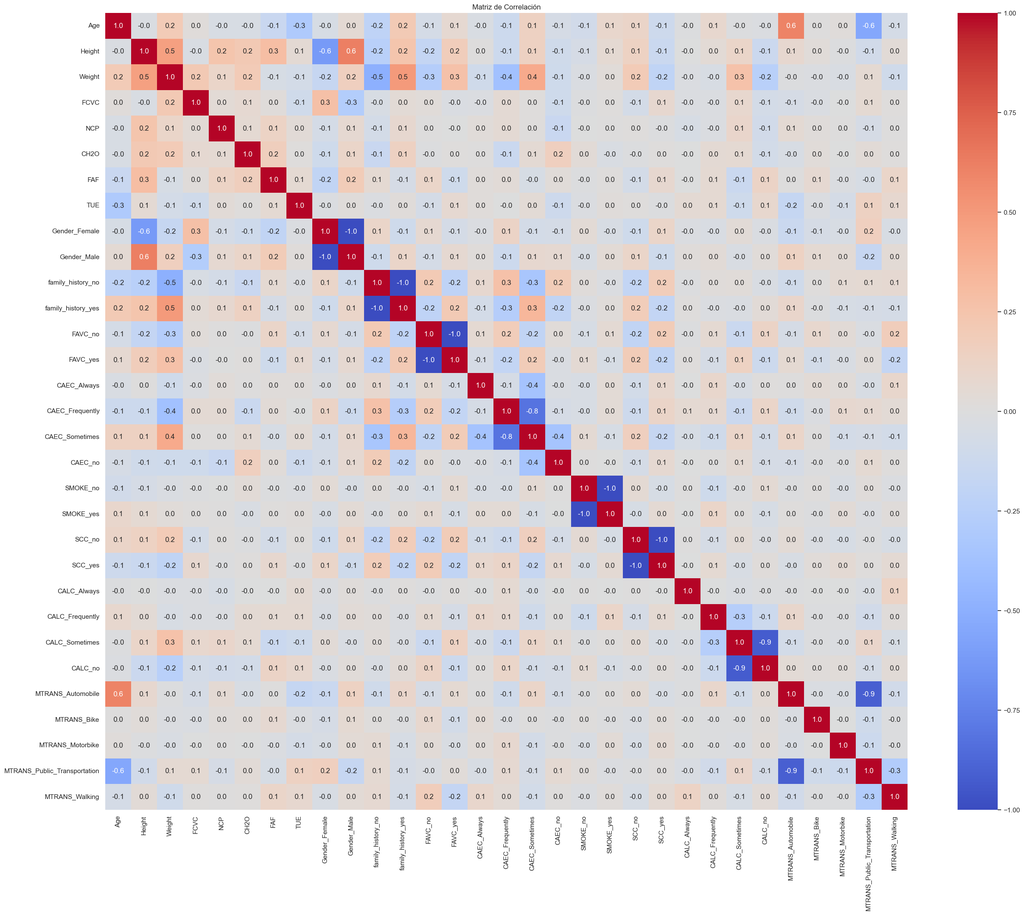

```python
plt.figure(figsize=(30, 24))
sns.heatmap(correlation_matrix, annot=True, cmap='coolwarm', fmt=".1f")
plt.title("Matriz de Correlación")
plt.show()
```

```python
# Nombres de las variables categóricas
new_categorical=list(df3.columns.values)
#print(new_categorical)
```

```python
# Calcular la inercia (suma de las distancias al cuadrado) para diferentes números de clusters
inertia = []
for n_clusters in range(1, 11):
    kproto = KPrototypes(n_clusters=n_clusters, init='Huang', verbose=2, n_init=10)
    clusters = kproto.fit_predict(df4, categorical=list(range(len(new_categorical))))
    inertia.append(kproto.cost_)
```

[output not shown]

[output cut: 753 more lines]

[output not shown]

```python
print(kproto.cluster_centroids_)
```

[output not shown]

[output cut: 85 more lines]

[output not shown]

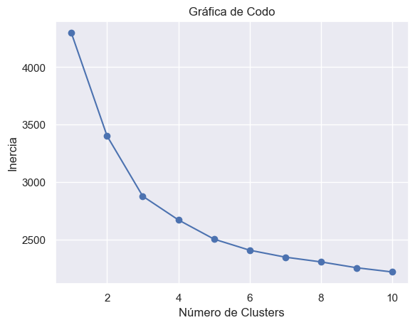

```python
# Generar gráfica de codo
plt.plot(range(1, 11), inertia, marker='o')
plt.xlabel('Número de Clusters')
plt.ylabel('Inercia')
plt.title('Gráfica de Codo')
plt.show()
```

```python
# Ejemplo con el número óptimo de clusters (reemplaza 'n_clusters_optimo' con tu elección)
n_clusters_optimo = 6
kproto = KPrototypes(n_clusters=n_clusters_optimo, init='Huang', verbose=2, n_init=10)
clusters = kproto.fit_predict(df4, categorical=list(range(len(new_categorical))))
```

[output not shown]

[output cut: 23 more lines]

[output not shown]

```python
# Agregar las etiquetas de cluster al DataFrame original
df4['Cluster'] = clusters

# Análisis descriptivo de los resultados
cluster_counts = df4['Cluster'].value_counts()
print("Número de instancias en cada cluster:")
print(cluster_counts)
```

```
Número de instancias en cada cluster:
Cluster
0    741
5    450
3    307
1    228
4    228
2    157
Name: count, dtype: int64
```

```python
df4.describe()
```

|  | Age | Height | Weight | FCVC | NCP | CH2O | FAF | TUE | Gender_Female | Gender_Male | ... | CALC_Always | CALC_Frequently | CALC_Sometimes | CALC_no | MTRANS_Automobile | MTRANS_Bike | MTRANS_Motorbike | MTRANS_Public_Transportation | MTRANS_Walking | Cluster |
| --- | --- | --- | --- | --- | --- | --- | --- | --- | --- | --- | --- | --- | --- | --- | --- | --- | --- | --- | --- | --- | --- |
| count | 2111.000000 | 2.111000e+03 | 2.111000e+03 | 2.111000e+03 | 2.111000e+03 | 2.111000e+03 | 2.111000e+03 | 2.111000e+03 | 2111.000000 | 2111.000000 | ... | 2111.000000 | 2111.000000 | 2111.000000 | 2111.000000 | 2111.000000 | 2111.000000 | 2111.000000 | 2111.000000 | 2111.000000 | 2111.000000 |
| mean | 0.000000 | -5.385449e-16 | -5.385449e-16 | -1.346362e-17 | 4.964711e-16 | 1.077090e-16 | 2.692725e-17 | -1.346362e-17 | 0.494079 | 0.505921 | ... | 0.000474 | 0.033160 | 0.663667 | 0.302700 | 0.216485 | 0.003316 | 0.005211 | 0.748460 | 0.026528 | 2.190905 |
| std | 1.000237 | 1.000237e+00 | 1.000237e+00 | 1.000237e+00 | 1.000237e+00 | 1.000237e+00 | 1.000237e+00 | 1.000237e+00 | 0.500083 | 0.500083 | ... | 0.021765 | 0.179096 | 0.472566 | 0.459535 | 0.411946 | 0.057502 | 0.072015 | 0.434001 | 0.160737 | 1.993362 |
| min | -1.625448 | -2.698006e+00 | -1.817304e+00 | -2.658379e+00 | -2.167023e+00 | -1.644905e+00 | -1.188039e+00 | -1.080625e+00 | 0.000000 | 0.000000 | ... | 0.000000 | 0.000000 | 0.000000 | 0.000000 | 0.000000 | 0.000000 | 0.000000 | 0.000000 | 0.000000 | 0.000000 |
| 25% | -0.688066 | -7.683883e-01 | -8.062914e-01 | -7.850187e-01 | -3.456952e-02 | -6.905894e-01 | -1.041630e+00 | -1.080625e+00 | 0.000000 | 0.000000 | ... | 0.000000 | 0.000000 | 0.000000 | 0.000000 | 0.000000 | 0.000000 | 0.000000 | 0.000000 | 0.000000 | 0.000000 |
| 50% | -0.241897 | -1.263207e-02 | -1.369510e-01 | -6.283450e-02 | 4.041527e-01 | -1.307326e-02 | -1.210937e-02 | -5.341135e-02 | 0.000000 | 1.000000 | ... | 0.000000 | 0.000000 | 1.000000 | 0.000000 | 0.000000 | 0.000000 | 0.000000 | 1.000000 | 0.000000 | 2.000000 |
| 75% | 0.265964 | 7.159595e-01 | 7.960531e-01 | 1.088342e+00 | 4.041527e-01 | 7.659959e-01 | 7.718565e-01 | 5.619968e-01 | 1.000000 | 1.000000 | ... | 0.000000 | 0.000000 | 1.000000 | 1.000000 | 0.000000 | 0.000000 | 0.000000 | 1.000000 | 0.000000 | 4.000000 |
| max | 5.782584 | 2.983646e+00 | 3.300136e+00 | 1.088342e+00 | 1.689740e+00 | 1.618759e+00 | 2.339750e+00 | 2.204618e+00 | 1.000000 | 1.000000 | ... | 1.000000 | 1.000000 | 1.000000 | 1.000000 | 1.000000 | 1.000000 | 1.000000 | 1.000000 | 1.000000 | 5.000000 |

8 rows × 32 columns

```python
# Exportar como csv
df4.to_csv(ruta + 'ObesityDataSet_raw_and_data_sinthetic_cluster.csv')
```

```python
df4.groupby('Cluster').count()
```

| Cluster | Age | Height | Weight | FCVC | NCP | CH2O | FAF | TUE | Gender_Female | Gender_Male | ... | SCC_yes | CALC_Always | CALC_Frequently | CALC_Sometimes | CALC_no | MTRANS_Automobile | MTRANS_Bike | MTRANS_Motorbike | MTRANS_Public_Transportation | MTRANS_Walking |
| --- | --- | --- | --- | --- | --- | --- | --- | --- | --- | --- | --- | --- | --- | --- | --- | --- | --- | --- | --- | --- | --- |
| 0 | 741 | 741 | 741 | 741 | 741 | 741 | 741 | 741 | 741 | 741 | ... | 741 | 741 | 741 | 741 | 741 | 741 | 741 | 741 | 741 | 741 |
| 1 | 228 | 228 | 228 | 228 | 228 | 228 | 228 | 228 | 228 | 228 | ... | 228 | 228 | 228 | 228 | 228 | 228 | 228 | 228 | 228 | 228 |
| 2 | 157 | 157 | 157 | 157 | 157 | 157 | 157 | 157 | 157 | 157 | ... | 157 | 157 | 157 | 157 | 157 | 157 | 157 | 157 | 157 | 157 |
| 3 | 307 | 307 | 307 | 307 | 307 | 307 | 307 | 307 | 307 | 307 | ... | 307 | 307 | 307 | 307 | 307 | 307 | 307 | 307 | 307 | 307 |
| 4 | 228 | 228 | 228 | 228 | 228 | 228 | 228 | 228 | 228 | 228 | ... | 228 | 228 | 228 | 228 | 228 | 228 | 228 | 228 | 228 | 228 |
| 5 | 450 | 450 | 450 | 450 | 450 | 450 | 450 | 450 | 450 | 450 | ... | 450 | 450 | 450 | 450 | 450 | 450 | 450 | 450 | 450 | 450 |

6 rows × 31 columns

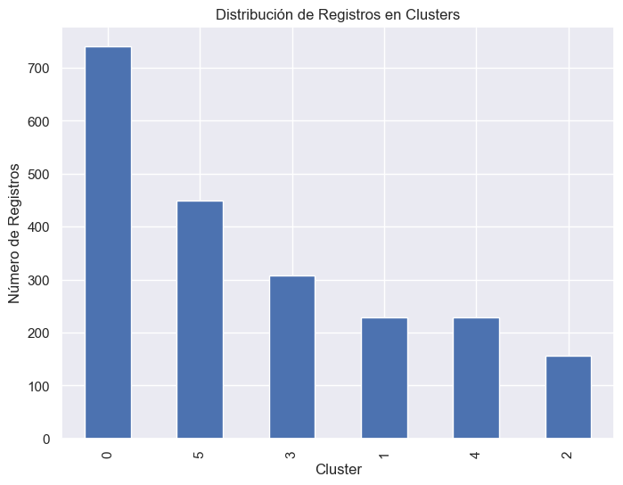

```python
# Estadísticas descriptivas para los clusters
cluster_stats = df4.groupby('Cluster').describe()

# Gráfico de barras para la distribución de los registros en clusters
cluster_counts = df4['Cluster'].value_counts()
plt.figure(figsize=(8, 6))
cluster_counts.plot(kind='bar')
plt.xlabel('Cluster')
plt.ylabel('Número de Registros')
plt.title('Distribución de Registros en Clusters')
plt.grid(True)
plt.show()
```